# Lab 1

Yuhao Wang, yw3204

September 9, 2018

# Instructions

Before you leave lab today make sure that you upload an RMarkdown file to the canvas page (this should have a .Rmd extension) as well as the html output after you have knitted the file (this will have a .html extension). Note that since you have already knitted this file, you should see both a **Lab1_UNI.html** and a **Lab1_UNI.Rmd** file in your GR5206 folder. Click on the **Files** tab to the right to see this. The files you upload to the Canvas page should be updated with commands you provide to answer each of the questions below. You can edit this file directly to produce your final solutions.

# Background: The Normal Distribution

Recall from your probability class that a random variable $X$ is normally-distributed with mean $\mu$ and variance $\sigma^2$ (denoted $X \sim N(\mu, \sigma^2)$) if it has a probability density function, or *pdf*, equal to

$$f(x) = \frac{1}{\sqrt{2\pi \sigma^2}} e^{-\frac{(x - \mu)^2}{2\sigma^2}}.$$

```r
rnorm(n = 5, mean = 10, sd = 3)
```

```
## [1]  8.120639 10.550930  7.493114 14.785842 10.988523
```

outputs 5 normally-distributed random variables with mean equal to 10 and standard deviation (this is $\sigma$) equal to 3. If the second and third arguments are ommited the default rates are **mean = 0** and **sd = 1**, which is referred to as the “standard normal distribution”.

# Tasks

## Sample means as sample size increases

1. Generate 100 random draws from the standard normal distribution and save them in a vector named **normal100**. Calculate the mean and standard deviation of **normal100**. In words explain why these values aren’t exactly equal to 0 and 1.

```r
# You'll want to type your response here.  Your response should look like:
# normal100 <-
# Of course, your answer should not be commented out.
normal100 <- rnorm(n = 100)
mean(normal100)
```

```
## [1] 0.08256659
```

```r
sd(normal100)
```

```
## [1] 0.8891336
```

```r
## Explanation: Because these samples are i.i.d. drawn from a standard distribution and
## the mean and standard deviation are both sample mean and sample sd., not pupolation
## mean and population sd..
```

2. The function **hist()** is a base *R* graphing function that plots a histogram of its input. Use **hist()** with your vector of standard normal random variables from question (1) to produce a histogram of the standard normal distribution. Remember that typing **?hist** in your console will provide help documents for the **hist()** function. If coded properly, these plots will be automatically embedded in your output file.

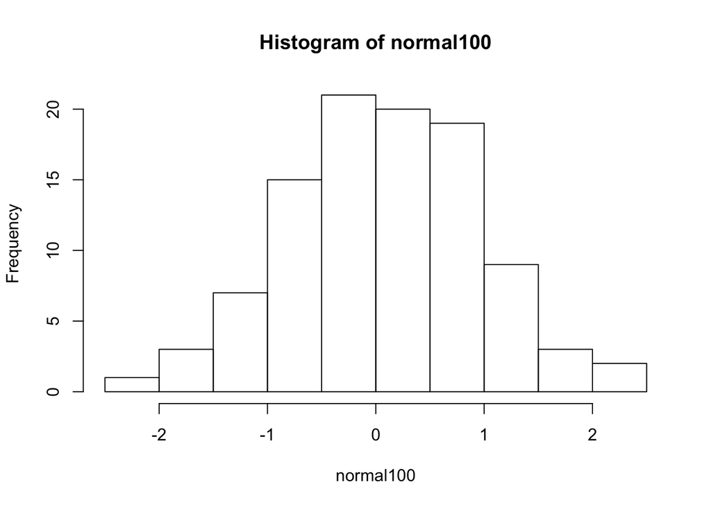

```r
hist(normal100)
```

3. Repeat question (1) except change the number of draws to 10, 1000, 10,000, and 100,000 storing the results in vectors called **normal10**, **normal1000**, **normal10000**, **normal100000**.

```r
normal10 <- rnorm(10)
normal1000 <- rnorm(1000)
normal10000 <- rnorm(10000)
normal100000 <- rnorm(100000)
```

4. We want to compare the means of our four random draws. Create a vector called **sample_means** that has as its first element the mean of **normal10**, its second element the mean of **normal100**, its third element the mean of **normal1000**, its fourth element the mean of **normal10000**, and its fifth element the mean of **normal100000**. After you have created the **sample_means** vector, print the contents of the vector and use the **length()** function to find the length of this vector. (it should be five). There are, of course, multiple ways to create this vector. Finally, explain in words the pattern we are seeing with the means in the **sample_means** vector.